# DATA 608 Final Project

# Data Type

Before continue working on our data, we’ll need to fix the class of some variables

```r
str(data)
```

```
## 'data.frame':    1516 obs. of  7 variables:
##  $ ï..Year                : int  2015 2015 2015 2015 2015 2015 2015 2015 2015 2015 ...
##  $ Leading.Cause          : chr  "Malignant Neoplasms (Cancer: C00-C97)" "Diseases of Heart (I00-I09, I11, I13, I20-I51)" "Cerebrovascular Disease (Stroke: I60-I69)" "Influenza (Flu) and Pneumonia (J09-J18)" ...
##  $ Sex                    : chr  "Female" "Female" "Female" "Female" ...
##  $ Race.Ethnicity         : chr  "Asian and Pacific Islander" "Asian and Pacific Islander" "Asian and Pacific Islander" "Asian and Pacific Islander" ...
##  $ Deaths                 : chr  "515" "498" "95" "89" ...
##  $ Death.Rate             : chr  "79.72666911" "77.09491499" "14.70686129" "13.7780069" ...
##  $ Age.Adjusted.Death.Rate: chr  "78.86538643" "81.60513144" "15.33793056" "14.70636233" ...
```

The data covered years from 2007 to 2017. So The first thing I wanted to do with the data was to look at how the number of deaths were changing each year. This was done using the code below and produced the ggplot graph under the code.

```r
NYC_Death <- suppressWarnings(transform(data, Deaths = as.double(Deaths), Death.Rate = as.double(Death.Rate), Age.Adjusted.Death.Rate = as.double(Age.Adjusted.Death.Rate)))
```

```r
skim(NYC_Death)
```

Data summary

| Name | NYC_Death |
| --- | --- |
| Number of rows | 1516 |
| Number of columns | 7 |
| _______________________ |  |
| Column type frequency: |  |
| character | 3 |
| numeric | 4 |
| ________________________ |  |
| Group variables | None |

**Variable type: character**

| skim_variable | n_missing | complete_rate | min | max | empty | n_unique | whitespace |
| --- | --- | --- | --- | --- | --- | --- | --- |
| Leading.Cause | 0 | 1 | 16 | 129 | 0 | 34 | 0 |
| Sex | 0 | 1 | 4 | 6 | 0 | 2 | 0 |
| Race.Ethnicity | 0 | 1 | 8 | 26 | 0 | 8 | 0 |

**Variable type: numeric**

| skim_variable | n_missing | complete_rate | mean | sd | p0 | p25 | p50 | p75 | p100 | hist |
| --- | --- | --- | --- | --- | --- | --- | --- | --- | --- | --- |
| ï..Year | 0 | 1.00 | 2012.01 | 3.18 | 2007.0 | 2009.0 | 2012.00 | 2015.0 | 2017.0 | ▇▆▅▆▆ |
| Deaths | 138 | 0.91 | 426.50 | 843.10 | 1.0 | 29.0 | 142.50 | 307.0 | 7050.0 | ▇▁▁▁▁ |
| Death.Rate | 543 | 0.64 | 53.63 | 75.04 | 2.4 | 12.1 | 18.86 | 70.1 | 491.4 | ▇▁▁▁▁ |
| Age.Adjusted.Death.Rate | 543 | 0.64 | 52.34 | 66.96 | 2.5 | 12.0 | 19.69 | 79.6 | 350.7 | ▇▁▁▁▁ |

#Total Death per year

```r
Total <- sum(NYC_Death$Deaths)
total_death_yr <- NYC_Death %>%
  group_by(ï..Year) %>%
  summarise(Total.Deaths = sum(Deaths, na.rm=T), .groups = 'drop')

total_death_yr
```

| ï..Year | Total.Deaths |
| --- | --- |
| 2007 | 53996 |
| 2008 | 54138 |
| 2009 | 52820 |
| 2010 | 52505 |
| 2011 | 52726 |
| 2012 | 52420 |
| 2013 | 53387 |
| 2014 | 53006 |
| 2015 | 54120 |
| 2016 | 54280 |

[output cut: 1 more lines]

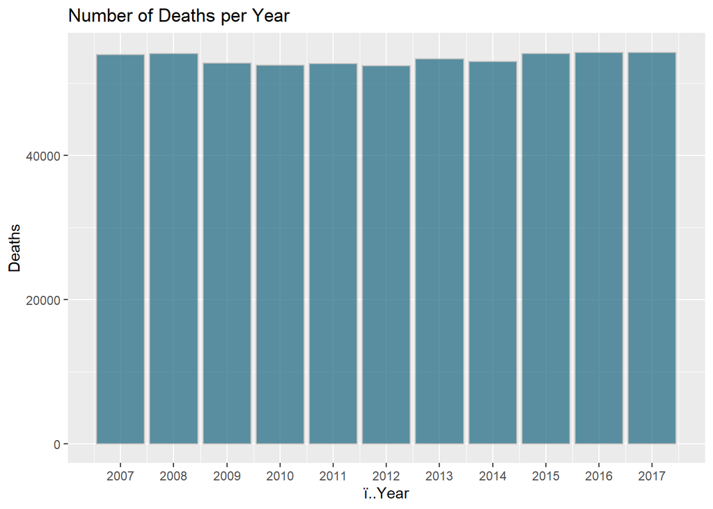

```r
ggplot(data = total_death_yr, aes(x = ï..Year,y = Total.Deaths)) +
  geom_bar(stat = "identity", color="grey", fill=rgb(0.1,0.4,0.5,0.7))+ scale_x_continuous(breaks = total_death_yr$ï..Year)+
  ggtitle("Number of Deaths per Year") +
  ylab(label = "Deaths" )
```